# ch4-exercise

# exercises.

### page 182 to 184. skipped for next time.

2. It was stated in the text that classifying an observation to the class for which (4.12) is largest is equivalent to classifying an observation to the class for which (4.13) is largest. Prove that this is the case. In other words, under the assumption that the observations in the kth class are drawn from a N(k,2) distribution, the Bayes classifier assigns an observation to the class for which the discriminant function is maximized.

— not sure how to demonstrate this.

# Applied

### page 185

10 This question should be answered using the Weekly data set, which is part of the ISLR package. This data is similar in nature to the Smarket data from this chapter’s lab, except that it contains 1, 089 weekly returns for 21 years, from the beginning of 1990 to the end of 2010.

1. Produce some numerical and graphical summaries of the Weekly data. Do there appear to be any patterns?

– from the pairs, we could see the (year and volume), (today and direction) have strong relationship, maybe the (volume and today) has some relationship.

```r
library(ISLR)
head(Weekly)
```

```
##   Year   Lag1   Lag2   Lag3   Lag4   Lag5    Volume  Today Direction
## 1 1990  0.816  1.572 -3.936 -0.229 -3.484 0.1549760 -0.270      Down
## 2 1990 -0.270  0.816  1.572 -3.936 -0.229 0.1485740 -2.576      Down
## 3 1990 -2.576 -0.270  0.816  1.572 -3.936 0.1598375  3.514        Up
## 4 1990  3.514 -2.576 -0.270  0.816  1.572 0.1616300  0.712        Up
## 5 1990  0.712  3.514 -2.576 -0.270  0.816 0.1537280  1.178        Up
## 6 1990  1.178  0.712  3.514 -2.576 -0.270 0.1544440 -1.372      Down
```

```r
dim(Weekly)
```

```
## [1] 1089    9
```

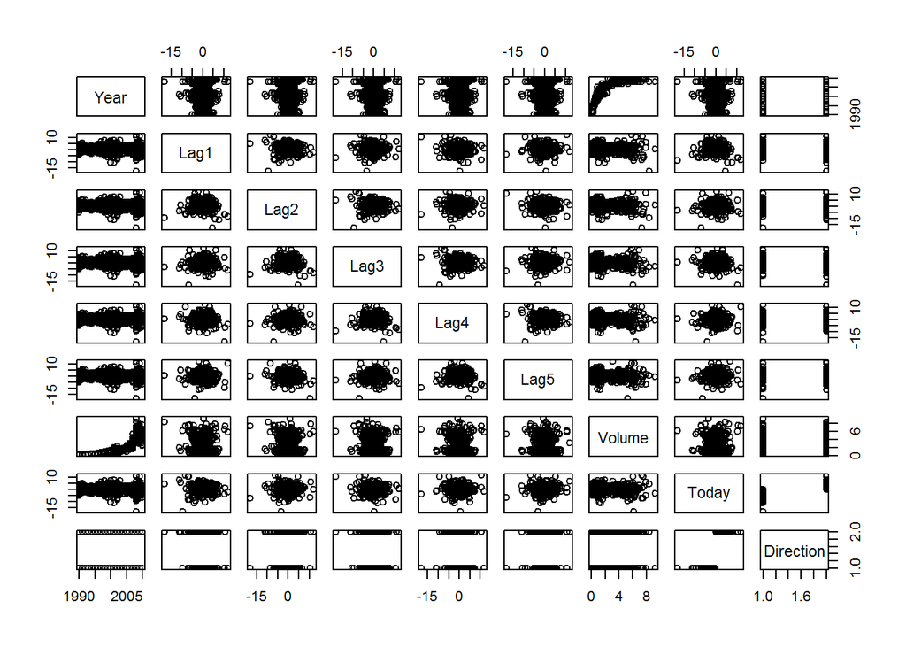

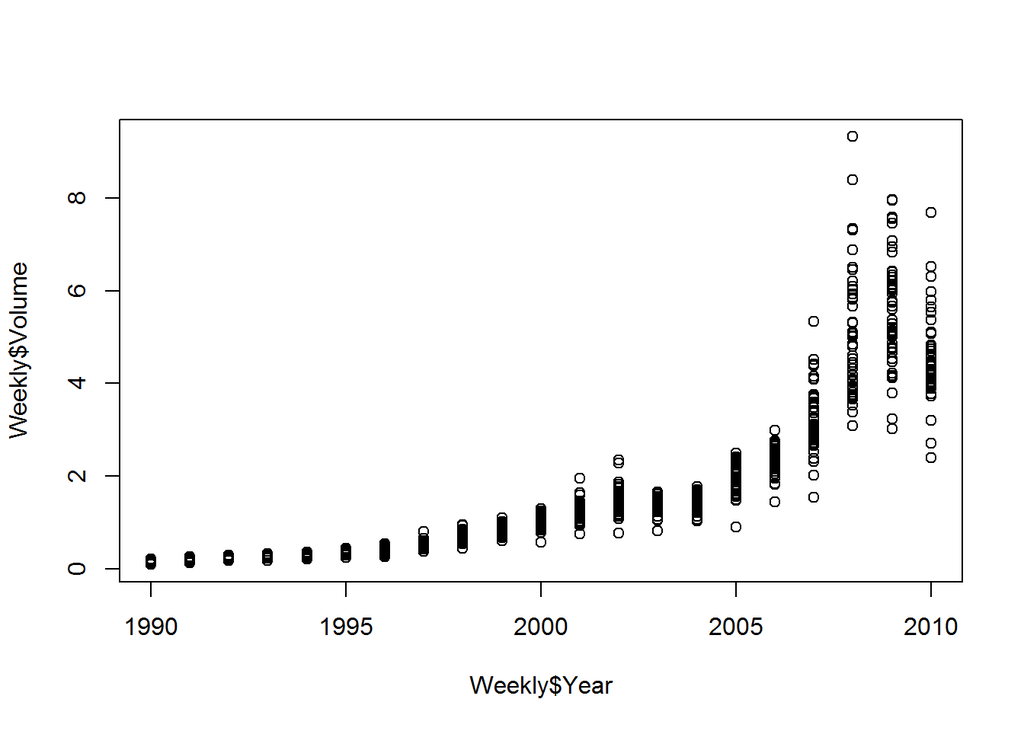

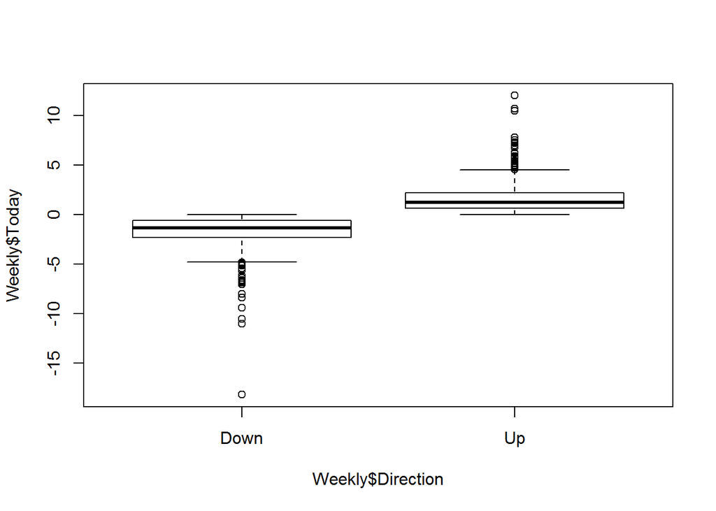

2. Use the full data set to perform a logistic regression with Direction as the response and the five lag variables plus Volume as predictors. Use the summary function to print the results. Do any of the predictors appear to be statistically significant? If so, which ones?

– Lag2 shows the statistically significant.

```r
names(Weekly)
```

```
## [1] "Year"      "Lag1"      "Lag2"      "Lag3"      "Lag4"      "Lag5"
## [7] "Volume"    "Today"     "Direction"
```

```r
weekly.fit = glm(Direction ~ Lag1 + Lag2 + Lag3 + Lag4 + Lag5 + Volume, data = Weekly, family = "binomial")
summary(weekly.fit)
```

```
##
## Call:
## glm(formula = Direction ~ Lag1 + Lag2 + Lag3 + Lag4 + Lag5 +
##     Volume, family = "binomial", data = Weekly)
##
## Deviance Residuals:
##     Min       1Q   Median       3Q      Max
## -1.6949  -1.2565   0.9913   1.0849   1.4579
##
## Coefficients:
##             Estimate Std. Error z value Pr(>|z|)
## (Intercept)  0.26686    0.08593   3.106   0.0019 **
## Lag1        -0.04127    0.02641  -1.563   0.1181
## Lag2         0.05844    0.02686   2.175   0.0296 *
## Lag3        -0.01606    0.02666  -0.602   0.5469
## Lag4        -0.02779    0.02646  -1.050   0.2937
## Lag5        -0.01447    0.02638  -0.549   0.5833
## Volume      -0.02274    0.03690  -0.616   0.5377
## ---
## Signif. codes:  0 '***' 0.001 '**' 0.01 '*' 0.05 '.' 0.1 ' ' 1
##
## (Dispersion parameter for binomial family taken to be 1)
##
##     Null deviance: 1496.2  on 1088  degrees of freedom
## Residual deviance: 1486.4  on 1082  degrees of freedom
## AIC: 1500.4
##
## Number of Fisher Scoring iterations: 4
```

3. Compute the confusion matrix and overall fraction of correct predictions. Explain what the confusion matrix is telling you about the types of mistakes made by logistic regression.

– the correct rate is around 56%, which should be lower if apply the regression into the actual condition.

```r
weekly.pre = predict(weekly.fit, Weekly, type = "response")
weekly.res = rep("Down", length(weekly.pre))
weekly.res[weekly.pre > .5] = "Up"
direction.label = Weekly$Direction
contrasts(Weekly$Direction)
```

```
##      Up
## Down  0
## Up    1
```

```r
table(weekly.res, direction.label)
```

```
##           direction.label
## weekly.res Down  Up
##       Down   54  48
##       Up    430 557
```

```r
mean(weekly.res == direction.label)
```

```
## [1] 0.5610652
```

```r
557/(557+430)
```

```
## [1] 0.5643364
```

```r
54/(54+48)
```

```
## [1] 0.5294118
```

4. Now fit the logistic regression model using a training data period from 1990 to 2008, with Lag2 as the only predictor. Compute the confusion matrix and the overall fraction of correct predictions for the held out data (that is, the data from 2009 and 2010).

–the error rate is similar as the (c) part, which also shows that only with Lag2 also could make the similar prediction.

```r
weekly.train = Weekly[which(Weekly$Year>=1990 & Weekly$Year<=2008), ]
weekly.test = Weekly[which(Weekly$Year<1990 | Weekly$Year>2008),]
weekly.glm_1 = glm(Direction ~ Lag2, data = weekly.train, family = "binomial")
weekly.pre_1 = predict(weekly.glm_1, Weekly, type = "response")
weekly.res_1 = rep("Down", length(weekly.pre_1))
weekly.res_1[weekly.pre_1>.5] = "Up"
table(weekly.res_1, direction.label)
```

```
##             direction.label
## weekly.res_1 Down  Up
##         Down   32  25
##         Up    452 580
```

```r
mean(weekly.res_1 == direction.label)
```

```
## [1] 0.5619835
```

```r
580/(452+580)
```

```
## [1] 0.5620155
```

```r
32/(32+25)
```

```
## [1] 0.5614035
```

–result is almost the same a the glm result according to the table result. (e) Repeat (d) using LDA.

```r
library(MASS)
weekly.lda = lda(Direction ~ Lag2, data = weekly.train)
weekly.lda.pre = predict(weekly.lda, Weekly, type = "response")
table(weekly.lda.pre$class, direction.label)
```

```
##       direction.label
##        Down  Up
##   Down   31  25
##   Up    453 580
```

```r
mean(weekly.lda.pre$class == direction.label)
```

```
## [1] 0.5610652
```

6. Repeat (d) using QDA. – the result is different than the lda and glm, there is no “down” estimation. it seems the regression is linear not suitable for the quadratic regression.

```r
weekly.qda = qda(Direction ~ Lag2, data = weekly.train)
weekly.qda.per = predict(weekly.qda, Weekly, type = "response")
table(weekly.qda.per$class, direction.label)
```

```
##       direction.label
##        Down  Up
##   Down    0   0
##   Up    484 605
```

```r
mean(weekly.qda.per$class == direction.label)
```

```
## [1] 0.5555556
```

7. Repeat (d) using KNN with K = 1. – the error rate is much lower than all the regression before. So I guess the regression is neither linear nor quadratic. which is much like un-regular one. Checked error rate by increasing k. higher k leads to higher error rate.

```r
train.X = cbind(weekly.train$Lag2)
test.X = cbind(Weekly$Lag2)
train.direction = weekly.train$Direction
test.direction = Weekly$Direction

library(class)
# for k = 1
weekly.knn = knn(train.X, test.X, train.direction, k = 1)
table(weekly.knn, test.direction)
```

```
##           test.direction
## weekly.knn Down  Up
##       Down  441  50
##       Up     43 555
```

```r
mean(weekly.knn == test.direction)
```

```
## [1] 0.9146006
```

```r
# for k = 5
weekly.knn = knn(train.X, test.X, train.direction, k = 5)
table(weekly.knn, test.direction)
```

```
##           test.direction
## weekly.knn Down  Up
##       Down  266 172
##       Up    218 433
```

```r
mean(weekly.knn == test.direction)
```

```
## [1] 0.6418733
```

```r
# for k = 10
weekly.knn = knn(train.X, test.X, train.direction, k = 10)
table(weekly.knn, test.direction)
```

```
##           test.direction
## weekly.knn Down  Up
##       Down  232 159
##       Up    252 446
```

```r
mean(weekly.knn == test.direction)
```

```
## [1] 0.6225895
```

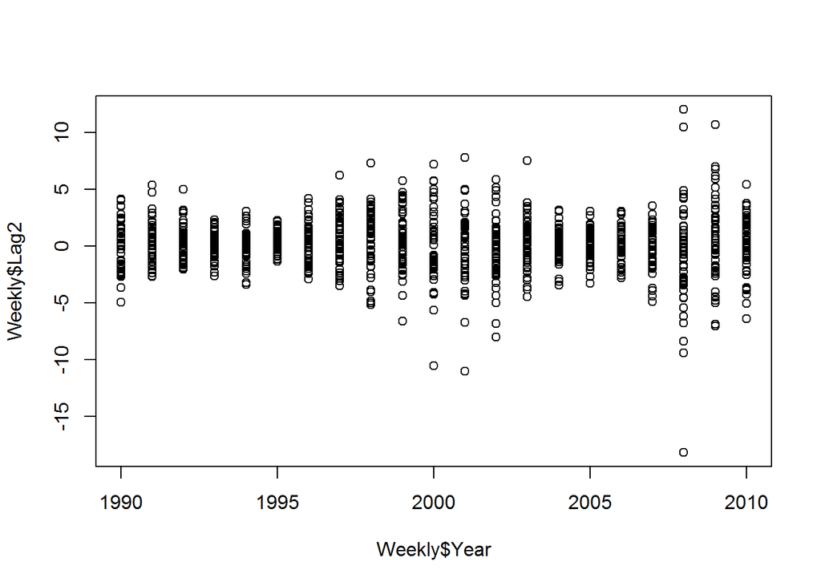

```r
plot(Weekly$Lag2 ~ Weekly$Year)
```

8. Which of these methods appears to provide the best results on this data? – it seems the knn provides the best result on the data.
9. Experiment with different combinations of predictors, including possible transformations and interactions, for each of the methods. Report the variables, method, and associated confusion matrix that appears to provide the best results on the held out data. Note that you should also experiment with values for K in the KNN classifier.

```r
weekly.glm.try = glm(Direction ~ Lag1 + Volume * Today, data = weekly.train, family = "binomial")
summary(weekly.glm.try)
```

```
##
## Call:
## glm(formula = Direction ~ Lag1 + Volume * Today, family = "binomial",
##     data = weekly.train)
##
## Deviance Residuals:
##        Min          1Q      Median          3Q         Max
## -2.380e-03  -2.000e-08   2.000e-08   2.000e-08   2.204e-03
##
## Coefficients:
##               Estimate Std. Error z value Pr(>|z|)
## (Intercept)    -17.524    554.296  -0.032    0.975
## Lag1            -4.761    261.303  -0.018    0.985
## Volume           7.030    286.826   0.025    0.980
## Today         1138.359  26991.927   0.042    0.966
## Volume:Today   -65.922  10250.634  -0.006    0.995
##
## (Dispersion parameter for binomial family taken to be 1)
##
##     Null deviance: 1.3547e+03  on 984  degrees of freedom
## Residual deviance: 1.2752e-05  on 980  degrees of freedom
## AIC: 10
##
## Number of Fisher Scoring iterations: 25
```

```r
weekly.glm.try = glm(Direction ~ exp(Volume), data = weekly.train, family = "binomial")
summary(weekly.glm.try)
```

```
##
## Call:
## glm(formula = Direction ~ exp(Volume), family = "binomial", data = weekly.train)
##
## Deviance Residuals:
##    Min      1Q  Median      3Q     Max
## -1.270  -1.270   1.088   1.088   1.375
##
## Coefficients:
##               Estimate Std. Error z value Pr(>|z|)
## (Intercept)  0.2145509  0.0643327   3.335 0.000853 ***
## exp(Volume) -0.0001498  0.0001967  -0.762 0.446250
## ---
## Signif. codes:  0 '***' 0.001 '**' 0.01 '*' 0.05 '.' 0.1 ' ' 1
##
## (Dispersion parameter for binomial family taken to be 1)
##
##     Null deviance: 1354.7  on 984  degrees of freedom
## Residual deviance: 1354.0  on 983  degrees of freedom
## AIC: 1358
##
## Number of Fisher Scoring iterations: 3
```

11. In this problem, you will develop a model to predict whether a given car gets high or low gas mileage based on the Auto data set.
1. Create a binary variable, mpg01, that contains a 1 if mpg contains a value above its median, and a 0 if mpg contains a value below its median. You can compute the median using the median() function. Note you may find it helpful to use the data.frame() function to create a single data set containing both mpg01 and the other Auto variables.

–done as below, but guess there should be some more convenience way to create this.

```r
head(Auto)
```

```
##   mpg cylinders displacement horsepower weight acceleration year origin
## 1  18         8          307        130   3504         12.0   70      1
## 2  15         8          350        165   3693         11.5   70      1
## 3  18         8          318        150   3436         11.0   70      1
## 4  16         8          304        150   3433         12.0   70      1
## 5  17         8          302        140   3449         10.5   70      1
## 6  15         8          429        198   4341         10.0   70      1
##                        name
## 1 chevrolet chevelle malibu
## 2         buick skylark 320
## 3        plymouth satellite
## 4             amc rebel sst
## 5               ford torino
## 6          ford galaxie 500
```

```r
Auto_mpg = Auto
mpg01 = rep(0, nrow(Auto))
Auto_mpg = cbind(Auto_mpg, mpg01)
avg_mpg = median(Auto_mpg$mpg)
Auto_mpg[which(Auto_mpg$mpg > avg_mpg), "mpg01"] =1
```

2. Explore the data graphically in order to investigate the association between mpg01 and the other features. Which of the other features seem most likely to be useful in predicting mpg01? Scatterplots and boxplots may be useful tools to answer this question. Describe your findings.

– according to the pairs plot, it seems mpg/ horsepower/ weight/ acceleration/ could helpful to predict the mpg01. – after checking in the boxplot, found acceleration is not as obvious as others. So, the element would impact the mpg prediction would be mpg/ horsepower/ weight.

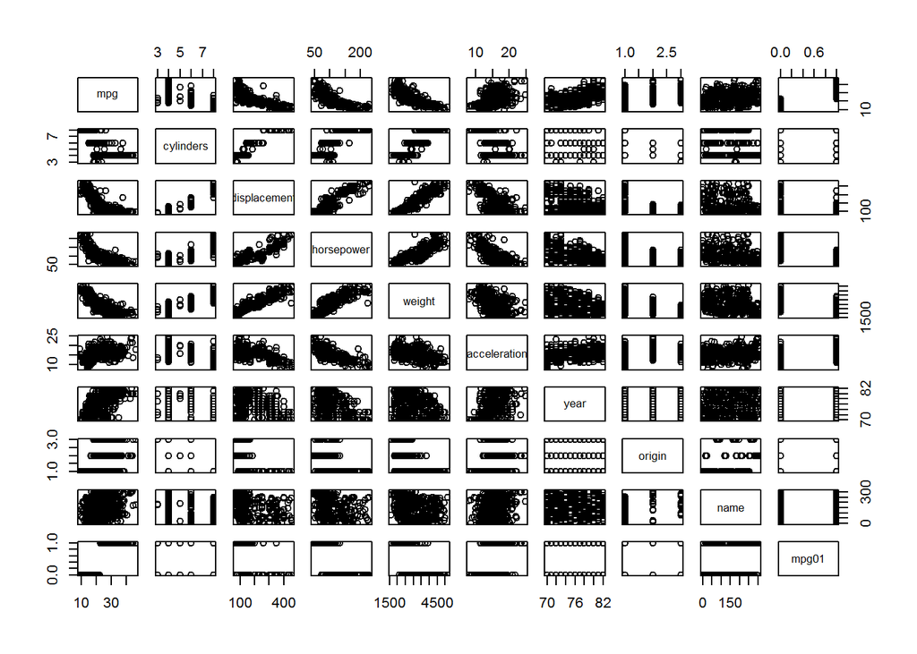

```r
pairs(Auto_mpg)
```

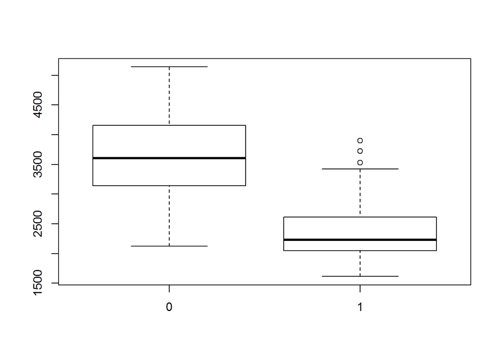

```r
boxplot(weight ~ mpg01, data = Auto_mpg)
```

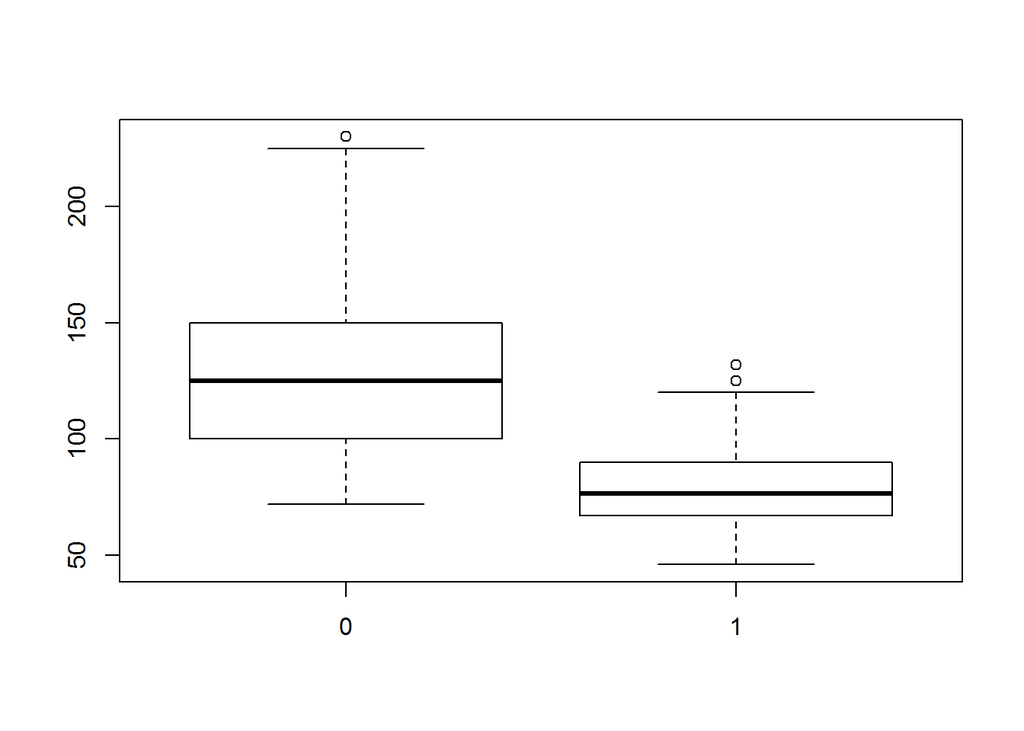

```r
boxplot(horsepower ~ mpg01, data = Auto_mpg)
```

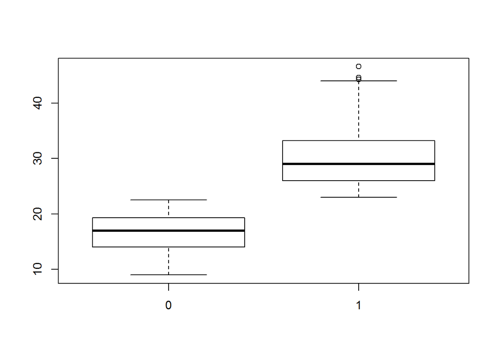

```r
boxplot(mpg ~ mpg01, data = Auto_mpg)
```

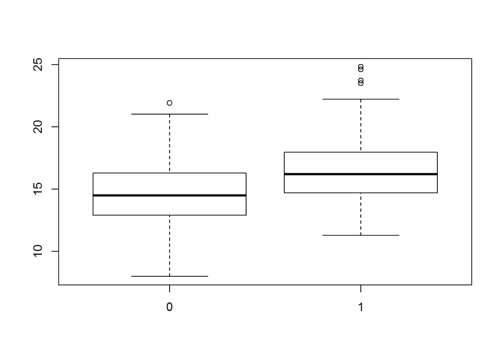

```r
boxplot(acceleration ~ mpg01, data = Auto_mpg)
```

3. Split the data into a training set and a test set.

```r
library(ISLR)
dim(Auto)
```

```
## [1] 392   9
```

```r
train_index = sample(c(TRUE, FALSE), size = nrow(Auto_mpg), replace = TRUE, prob = c(.8, .2))
Auto_train = Auto_mpg[train_index, ]
Auto_test = Auto_mpg[!train_index, ]
```

4. Perform LDA on the training data in order to predict mpg01 using the variables that seemed most associated with mpg01 in (b). What is the test error of the model obtained?

```r
library(MASS)
Auto_lda = lda(mpg01 ~ horsepower + weight + acceleration, data = Auto_train)
Auto_lda_predict = predict(Auto_lda, Auto_test, response = "class")
Auto_lda_pre_class = Auto_lda_predict$class
mean(Auto_lda_pre_class == Auto_test$mpg01)
```

```
## [1] 0.8780488
```

```r
table(Auto_lda_pre_class, Auto_test$mpg01)
```

```
##
## Auto_lda_pre_class  0  1
##                  0 35  4
##                  1  6 37
```

5. Perform QDA on the training data in order to predict mpg01 using the variables that seemed most associated with mpg01 in (b). What is the test error of the model obtained?

```r
Auto_qda = qda(mpg01 ~ horsepower + weight + acceleration, data = Auto_train)
Auto_qda_pre = predict(Auto_qda, Auto_test)
Auto_qda_pre_label = Auto_qda_pre$class
mean(Auto_qda_pre_label == Auto_test$mpg01)
```

```
## [1] 0.902439
```

```r
table(Auto_qda_pre_label, Auto_test$mpg01)
```

```
##
## Auto_qda_pre_label  0  1
##                  0 37  4
##                  1  4 37
```

6. Perform logistic regression on the training data in order to predict mpg01 using the variables that seemed most associated with mpg01 in (b). What is the test error of the model obtained?

```r
Auto_glm = glm(mpg01 ~ horsepower + weight + acceleration, data = Auto_train, family = "binomial")
Auto_glm_pre = predict(Auto_glm, Auto_test, type = "response")
Auto_glm_pre_label = rep(0, nrow(Auto_test))
Auto_glm_pre_label[which(Auto_glm_pre >.5)] = 1

table(Auto_glm_pre_label, Auto_test$mpg01)
```

```
##
## Auto_glm_pre_label  0  1
##                  0 36 11
##                  1  5 30
```

```r
mean(Auto_glm_pre_label == Auto_test$mpg01)
```

```
## [1] 0.804878
```

7. Perform KNN on the training data, with several values of K, in order to predict mpg01. Use only the variables that seemed most associated with mpg01 in (b). What test errors do you obtain? Which value of K seems to perform the best on this data set?

```r
dim(Auto_train)
```

```
## [1] 310  10
```

```r
Auto_train.X = cbind(Auto_train$horsepower, Auto_train$weight, Auto_train$acceleration)
Auto_test.X = cbind(Auto_test$horsepower, Auto_test$weight, Auto_test$acceleration)
nrow(Auto_test.X)
```

```
## [1] 82
```

```r
Auto_train.label = Auto_train$mpg01
Auto_test.label = Auto_test$mpg01
library(class)
Auto_knn_pre = knn(Auto_train.X, Auto_test.X, Auto_train.label, k = 30)
mean(Auto_knn_pre == Auto_test.label)
```

```
## [1] 0.8658537
```

```r
table(Auto_knn_pre, Auto_test.label)
```

```
##             Auto_test.label
## Auto_knn_pre  0  1
##            0 38  8
##            1  3 33
```

12. This problem involves writing functions.
1. Write a function, Power(), that prints out the result of raising 2 to the 3rd power. In other words, your function should compute 2^3 and print out the results. Hint: Recall that x^a raises x to the power a. Use the print() function to output the result.

```r
Power <- function(){
  return (2^3)
}
Power()
```

```
## [1] 8
```

2. Create a new function, Power2(), that allows you to pass any two numbers, x and a, and prints out the value of x^a. You can do this by beginning your function with the line: > Power2=function(x,a){ You should be able to call your function by entering, for instance, > Power2(3,8) on the command line. This should output the value of 3^8, namely, 6, 561.

```r
Power2 <- function(x, a){
  return(x^a)
}
Power2(3, 8)
```

```
## [1] 6561
```

3. Using the Power2() function that you just wrote, compute 10^3, 8^17, and 131^3.

```r
Power2(10, 3)
```

```
## [1] 1000
```

```r
Power2(8, 17)
```

```
## [1] 2.2518e+15
```

```r
Power2(131, 3)
```

```
## [1] 2248091
```

4. Now create a new function, Power3(), that actually returns the result x^a as an R object, rather than simply printing it to the screen. That is, if you store the value x^a in an object called result within your function, then you can simply return() this return() result, using the following line: > return (result)

The line above should be the last line in your function, before the } symbol.

```r
Power3 <- function(x, a){
  return(x^a)
}
```

5. Now using the Power3() function, create a plot of f(x) = x2. The x-axis should display a range of integers from 1 to 10, and the y-axis should display x2. Label the axes appropriately, and use an appropriate title for the figure. Consider displaying either the x-axis, the y-axis, or both on the log-scale. You can do this by using log=‘’x’‘, log=’‘y’‘, or log=’‘xy’’ as arguments to the plot() function. – both log x and log y, the plot would convert to a straight line. either plot x or plot y, the plot line would still be a curve.

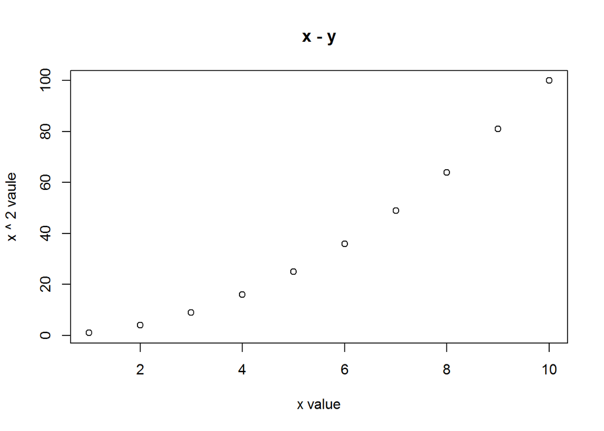

```r
x <- 1:10
y <- Power3(x, 2)
plot(x, y, main = "x - y", xlab = "x value", ylab = "x ^ 2 vaule")
```

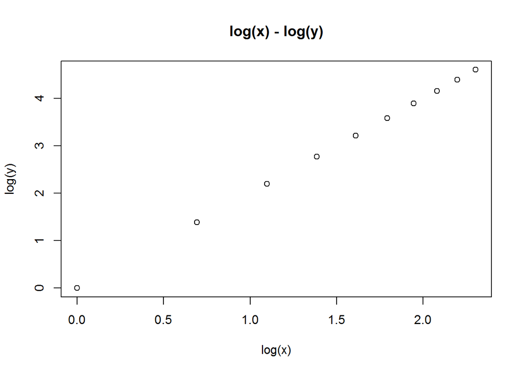

```r
plot(log(x), log(y), main = "log(x) - log(y)", xlab = "log(x)", ylab = "log(y)")
```

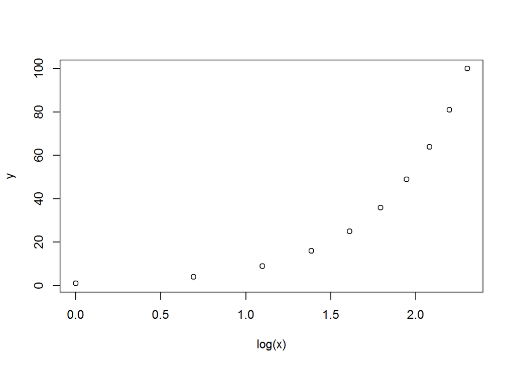

```r
plot(log(x), y)
```

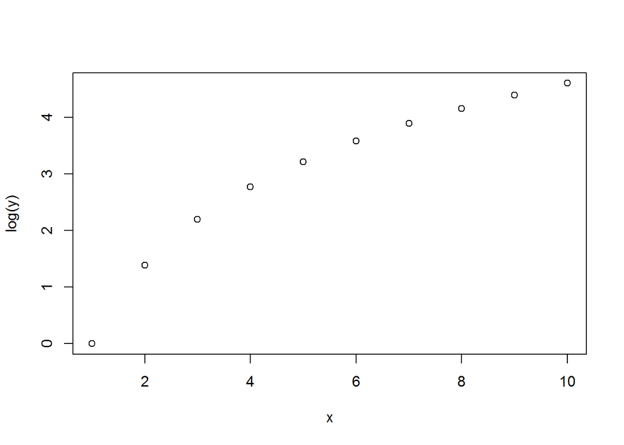

```r
plot(x, log(y))
```

6. Create a function, PlotPower(), that allows you to create a plot of x against x^a for a fixed a and for a range of values of x. For instance, if you call > PlotPower(1:10,3) then a plot should be created with an x-axis taking on values 1, 2, . . . , 10, and a y-axis taking on values 1^3, 2^3, . . . , 10^3.

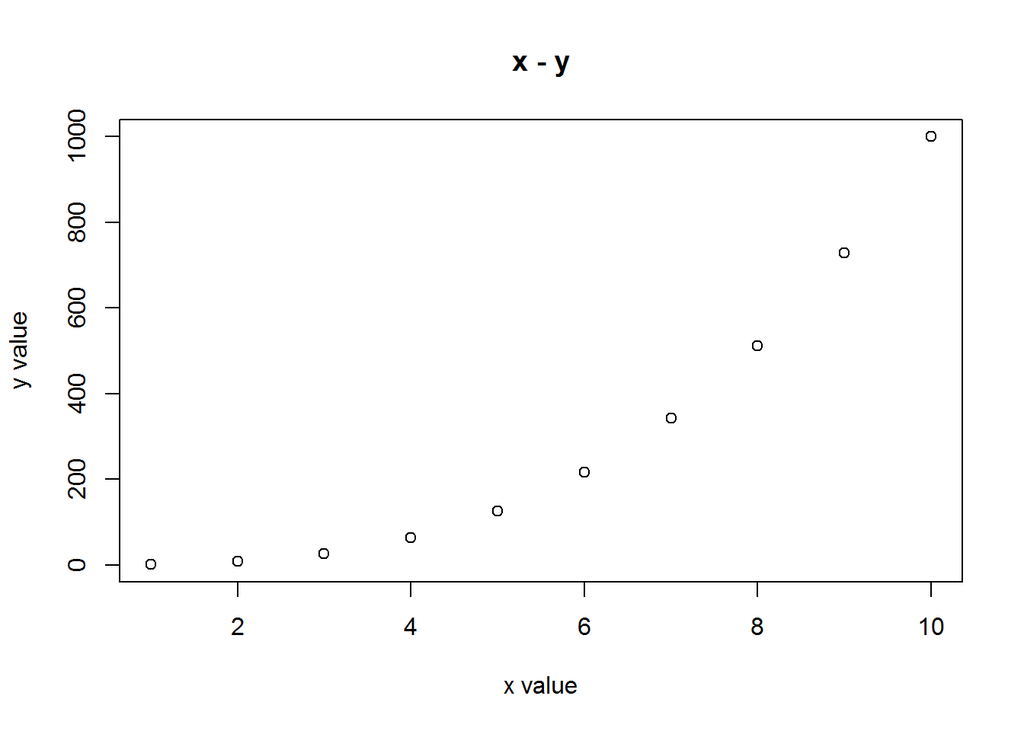

```r
PlotPower <- function(x, a){
  y <- x^a
  plot(x, y, main = "x - y", xlab = "x value", ylab = "y value")
}
PlotPower(1:10, 3)
```

13. Using the Boston data set, fit classification models in order to predict whether a given suburb has a crime rate above or below the median. Explore logistic regression, LDA, and KNN models using various subsets of the predictors. Describe your findings.

– use pairs to check the data. some data has the unusual shape like,

[figure not shown]

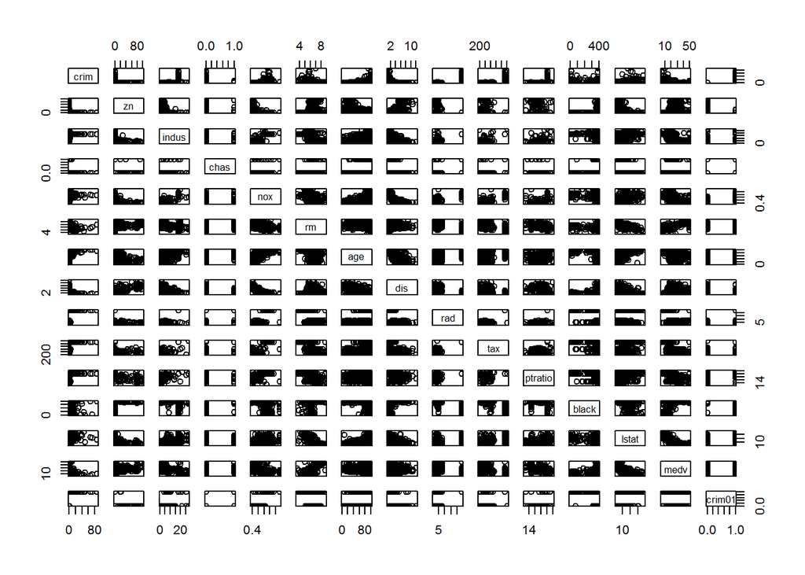

```r
#this is to add crim data into the Boston data
Boston_crim <- Boston
crim_mean <- median(Boston$crim)
crim01 <- rep(0, nrow(Boston))
Boston_crim <- cbind(Boston, crim01)
Boston_crim[which(Boston_crim$crim > crim_mean), "crim01"] = 1

#get the rough info from the data
pairs(Boston_crim)
```